# ch10_path_following

## Tips and Hints

Note that the unit tests for Chapter 10 are quite exhaustive and can take 5-10 minutes to run. You may want to avoid running them each time you develop something in the Jupyter notebook. Also, keep in mind that you can run them separately using the following command.

```
python .\mav_sim\unit_tests\ch10_path_follower_test.py
```

You may find it easier to do your development outside of the Jupyter notebook using the "book_assignments\mavsim_chap10.py." However, make sure to insert the solution for each problem into Jupyter before exporting.

Numpy dot() and cross() functions require that the inputs be of the shape (3,) (i.e., a vector, not a matrix). I would recommend doing a little math beforehand and realize that the cross product is greatly simplified when the second vector is (0,0,1)^T.

## Problem 0: Path follower implementation

In `chap10.path_follower.py` implement the following two functions

- `follow_straight_line(...)`
- `follow_orbit(...)`

A few notes on implementation:

- Ensure to populate the entire autopilot command for each function
- Use the `wrap(...)` function as appropriate
- Only return a non-zero roll feed forward term for the circular orbit when $\frac{d-\rho}{\rho} < 10$
- Calculate the roll feed forward term assuming no wind

```python
import sys
import numpy as np
import os
# Configure Qt to use XCB (X11) instead of Wayland for better OpenGL support in Jupyt
# This provides native 3D visualization support
os.environ['QT_API'] = 'pyqt5'
os.environ['QT_QPA_PLATFORM'] = 'xcb'
# Add the parent directory to the Python path so mav_sim can be imported
sys.path.insert(0, os.path.abspath('..'))
from mav_sim.chap3.mav_dynamics import DynamicState
from mav_sim.chap10.run_sim import run_sim
from mav_sim.message_types.msg_path import MsgPath
from mav_sim.message_types.msg_state import MsgState
from mav_sim.message_types.msg_sim_params import MsgSimParams
from typing import Callable

from mav_sim.chap10.path_viewer import PathViewer
from mav_sim.chap3.data_viewer import DataViewer
from mav_sim.tools.display_figures import display_data_view, display_mav_view

# The viewers need to be initialized once due to restart issues with qtgraph
if 'path_view' not in globals():
    print("Initializing mav_view")
    global path_view
    path_view = PathViewer()  # initialize the mav viewer
if 'data_view' not in globals():
    print("Initializing data_view")
    global data_view
    data_view = DataViewer()  # initialize view of data plots

# Initialize the simulation parameters
sim_params_default = MsgSimParams(end_time=50.) # Sim ending in 10 seconds
state = DynamicState()

# Function for running simulation and displaying results
def run_sim_and_display(path_fnc: Callable[ [float, MsgState], MsgPath], sim_params: MsgSimParams = sim_params_default):
    global path_view
    global data_view
    data_view.reset(sim_params.start_time)
    (path_view, data_view) = run_sim(sim=sim_params, path_fnc=path_fnc, init_state=state, path_view=path_view, data_view=data_view)
    display_data_view(data_view)
    display_mav_view(path_view)
```

```
Initializing mav_view
Initializing data_view
```

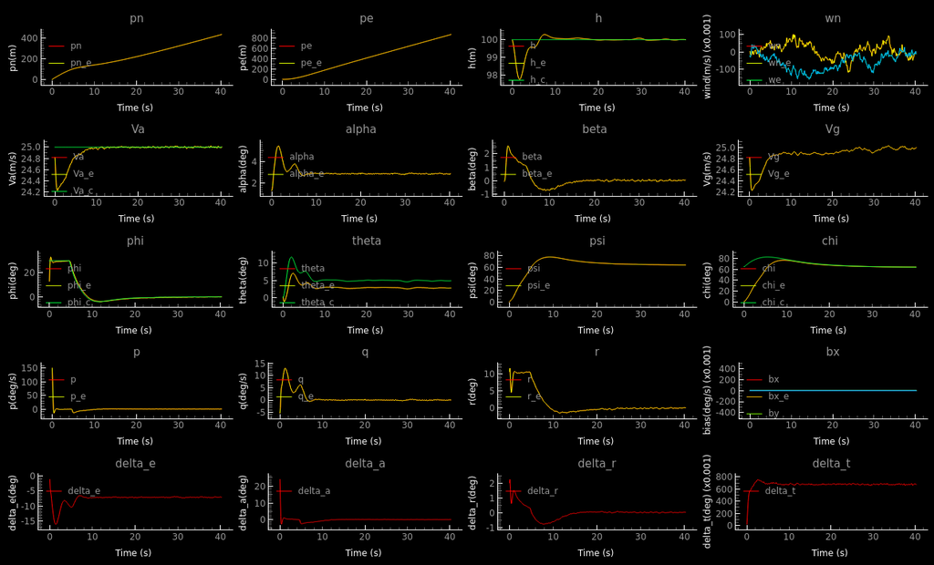

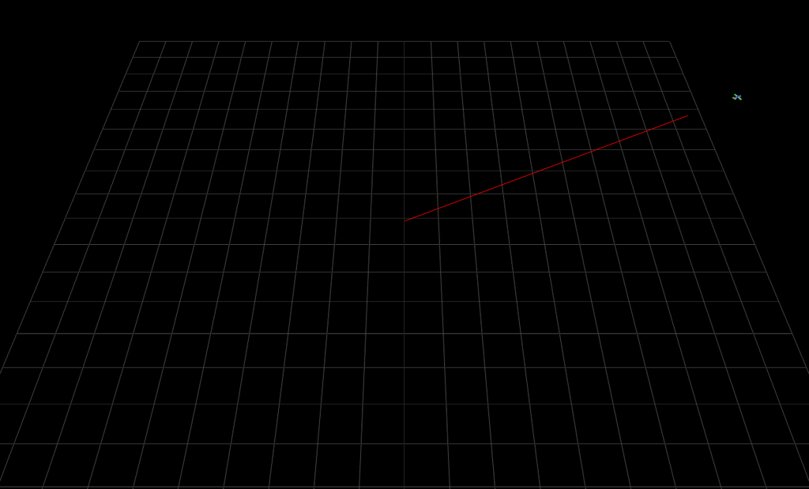

```python
# path definition
path = MsgPath()
path.type = "line"
path.line_origin = np.array([[0.0, 0.0, -100.0]]).T
path.line_direction = np.array([[0.5, 1.0, 0.0]]).T
path.line_direction = path.line_direction / np.linalg.norm(path.line_direction)

# Constant path function definition
def constant_path(time: float, state: MsgState) -> MsgPath:
    return path

# Follow path
run_sim_and_display(path_fnc=constant_path)
```

## Problem 1: Achievable Line Defined Between Points

Control the aircraft to follow a straight line path at 20 m/s where the line is defined by the points $w_0^i = \begin{bmatrix}0 \\ 2 \\ -100 \end{bmatrix}$ and $w_1^i = \begin{bmatrix}50 \\ 10 \\ -100 \end{bmatrix}$

### Describe the results

The aircraft converges smoothly to the desired straight-line path and tracks it accurately. Since the line is horizontal (no altitude change) and the airspeed is achievable, the path follower maintains stable course and altitude throughout the simulation.

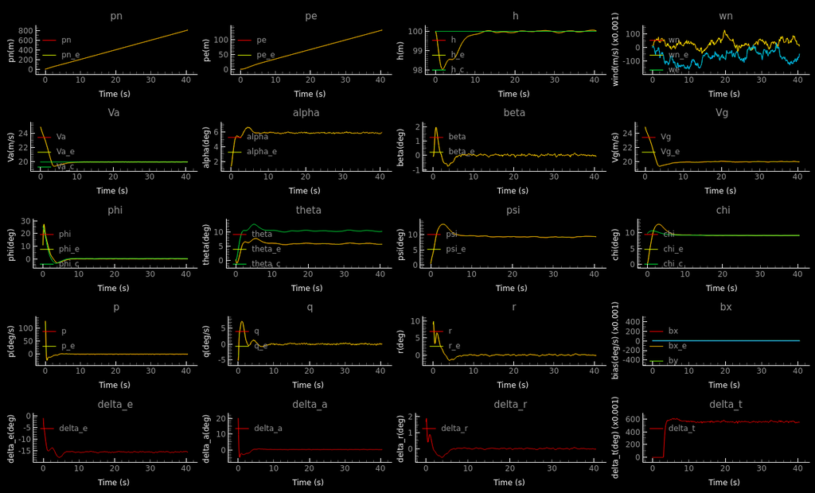

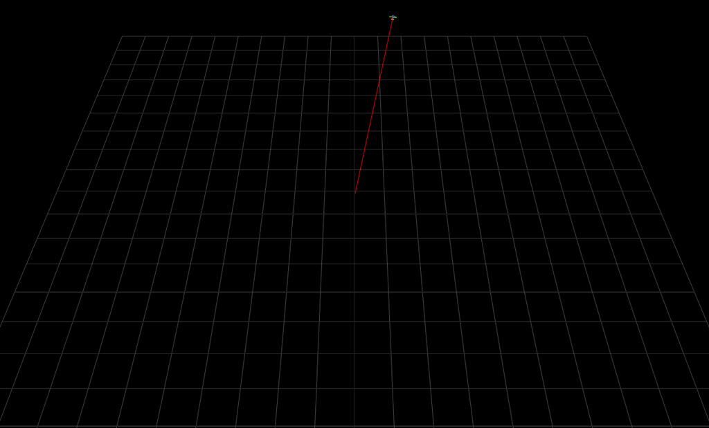

```python
# Problem 1: Straight line at 20 m/s between w0 and w1
w0 = np.array([[0.0, 2.0, -100.0]]).T
w1 = np.array([[50.0, 10.0, -100.0]]).T

path1 = MsgPath()
path1.type = "line"
path1.airspeed = 20.0
path1.line_origin = w0
q = w1 - w0
path1.line_direction = q / np.linalg.norm(q)

def path1_fnc(time: float, state: MsgState) -> MsgPath:
    return path1

run_sim_and_display(path_fnc=path1_fnc)
```

## Problem 2: Near-Achievable Line Defined Between Points

Control the aircraft to follow a straight line path at 30 m/s where the line is defined by the points $w_0^i = \begin{bmatrix}0 \\ 2 \\ -100 \end{bmatrix}$ and $w_1^i = \begin{bmatrix}100 \\ 200 \\ -150 \end{bmatrix}$

### Describe the results

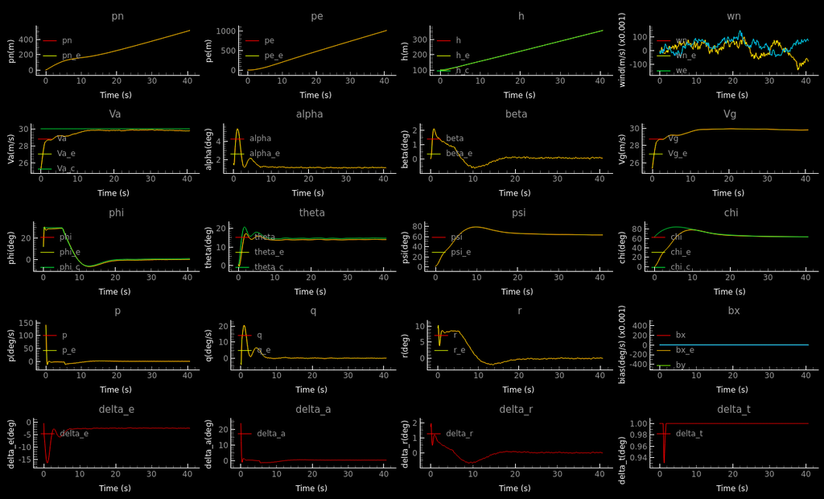

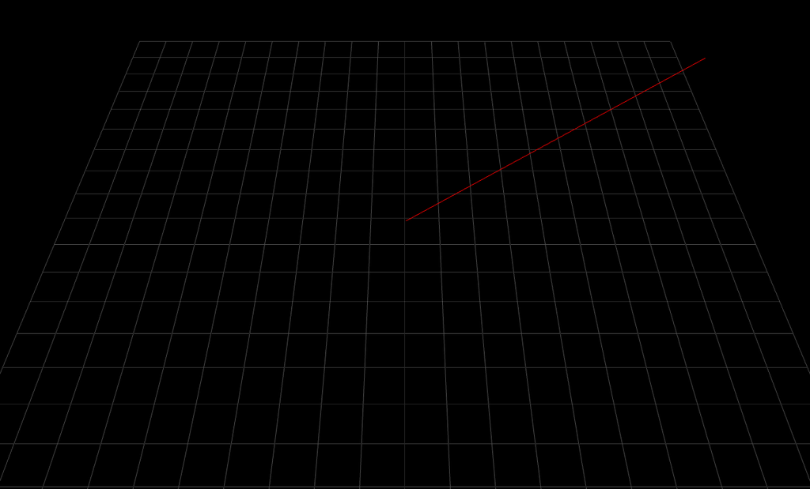

```python
# Problem 2: Straight line at 30 m/s between w0 and w1
w0 = np.array([[0.0, 2.0, -100.0]]).T
w1 = np.array([[100.0, 200.0, -150.0]]).T

path2 = MsgPath()
path2.type = "line"
path2.airspeed = 30.0
path2.line_origin = w0
q = w1 - w0
path2.line_direction = q / np.linalg.norm(q)

def path2_fnc(time: float, state: MsgState) -> MsgPath:
    return path2

run_sim_and_display(path_fnc=path2_fnc)
```

## Problem 3: Non-Achievable Line Defined Between Points

Control the aircraft to follow a straight line path at 30 m/s where the line is defined by the points $w_0^i = \begin{bmatrix}0 \\ 2 \\ -100 \end{bmatrix}$ and $w_1^i = \begin{bmatrix}100 \\ 200 \\ -200 \end{bmatrix}$

### What do you notice about the z-component of the line direction definition and the ability to track the line?

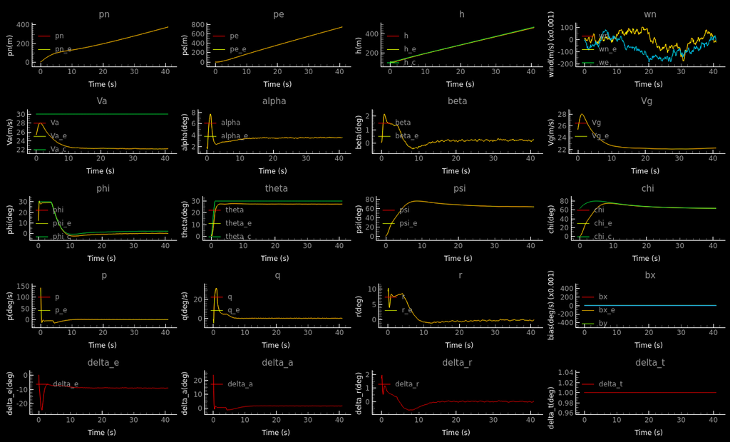

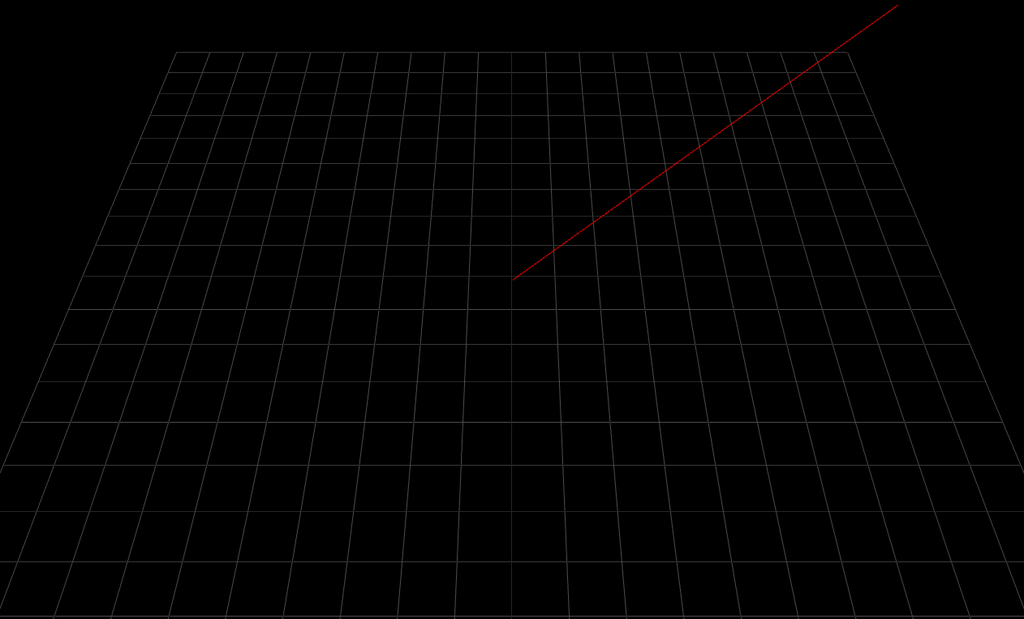

```python
# Problem 3: Straight line at 30 m/s between w0 and w1 (non-achievable)
w0 = np.array([[0.0, 2.0, -100.0]]).T
w1 = np.array([[100.0, 200.0, -200.0]]).T

path3 = MsgPath()
path3.type = "line"
path3.airspeed = 30.0
path3.line_origin = w0
q = w1 - w0
path3.line_direction = q / np.linalg.norm(q)

def path3_fnc(time: float, state: MsgState) -> MsgPath:
    return path3

run_sim_and_display(path_fnc=path3_fnc)
```

## Problem 4: Trackable Orbit definition

Control the aircraft in a clockwise circular orbit around the point $w_0^i = \begin{bmatrix}400 \\ 200 \\ -100 \end{bmatrix}$ at a radius of 200 meters and airspeed of 25 m/s.

### Describe the results

The aircraft converges to and tracks the clockwise circular orbit smoothly. The 200 m radius is well above the minimum turn radius for 25 m/s, so the aircraft can comfortably maintain the orbit with steady bank angle and altitude.

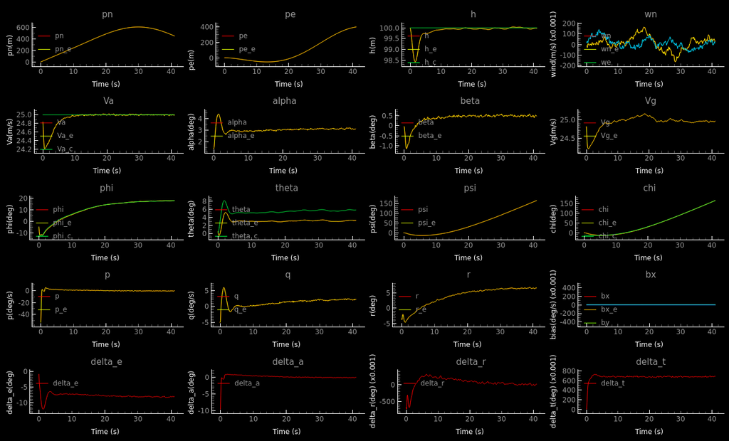

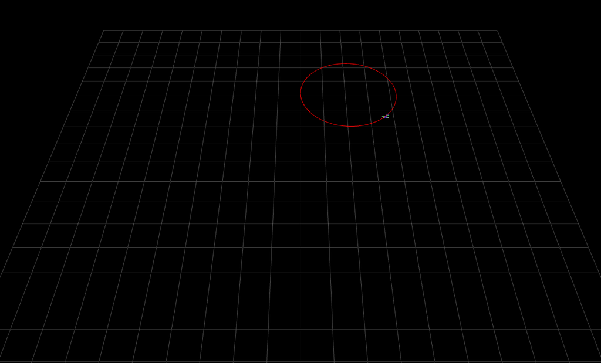

```python
# Problem 4: CW orbit at (400, 200, -100), r=200, 25 m/s
path4 = MsgPath()
path4.type = "orbit"
path4.airspeed = 25.0
path4.orbit_center = np.array([[400.0, 200.0, -100.0]]).T
path4.orbit_radius = 200.0
path4.orbit_direction = "CW"

def path4_fnc(time: float, state: MsgState) -> MsgPath:
    return path4

run_sim_and_display(path_fnc=path4_fnc)
```

## Problem 5: UnTrackable Orbit definition

Control the aircraft in a counter-clockwise circular orbit around the point $w_0^i = \begin{bmatrix}100 \\ -100 \\ -100 \end{bmatrix}$ at a radius of 75 meters and airspeed of 25 m/s.

### What do you notice about the radius and the ability to track the orbit?

The minimum turn radius is determined by $R_{min} = V_a^2 / (g \tan \phi_{max})$. At 25 m/s, the 75 m radius requires a bank angle steeper than the aircraft can achieve, making the orbit untrackable. Larger radii (like 200 m in Problem 4) are achievable because they require less aggressive bank angles.

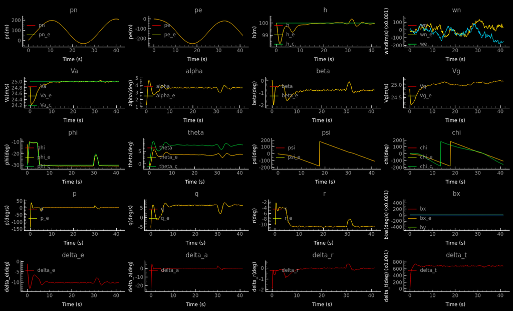

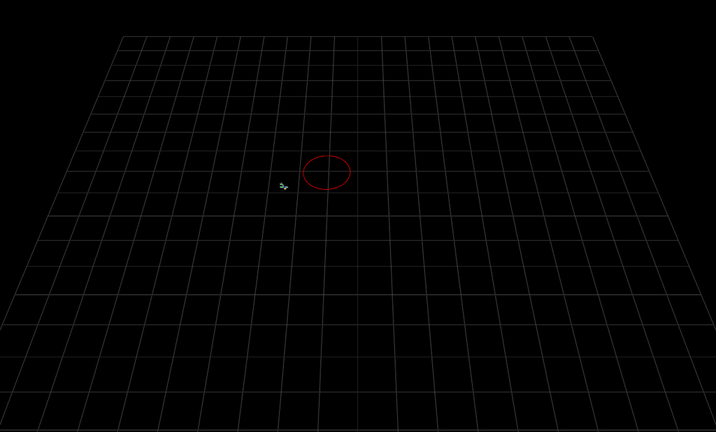

```python
# Problem 5: CCW orbit at (100, -100, -100), r=75, 25 m/s
path5 = MsgPath()
path5.type = "orbit"
path5.airspeed = 25.0
path5.orbit_center = np.array([[100.0, -100.0, -100.0]]).T
path5.orbit_radius = 75.0
path5.orbit_direction = "CCW"

def path5_fnc(time: float, state: MsgState) -> MsgPath:
    return path5

run_sim_and_display(path_fnc=path5_fnc)
```

## Problem 6: Switching control with no transition

Control the aircraft at 25 m/s using straight-line paths to move between waypoints $w_0^i = \begin{bmatrix}0 \\ 0 \\ -100 \end{bmatrix}$, $w_1^i = \begin{bmatrix}600 \\ 0 \\ -100 \end{bmatrix}$, $w_2^i = \begin{bmatrix}600 \\ 1 \\ -100 \end{bmatrix}$. Switch from executing linesegment $\overline{w_0 w_1}$ to $\overline{w_1 w_2}$ when the aircraft's north position is greater than or equal to the north position of $w_1^i$.

### Describe the quality of the path following

The path following is poor at the transition point. The hard switch causes an abrupt change in commanded course from north to east, resulting in a large overshoot past $w_1$ before the aircraft can turn and converge onto the second line segment. There is no smooth transition between the two paths.

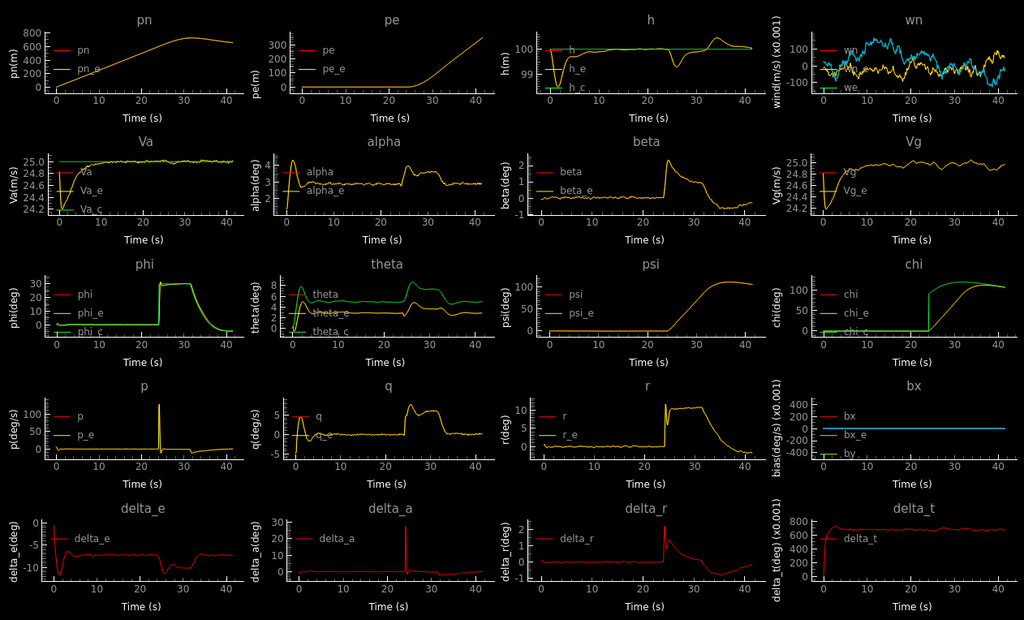

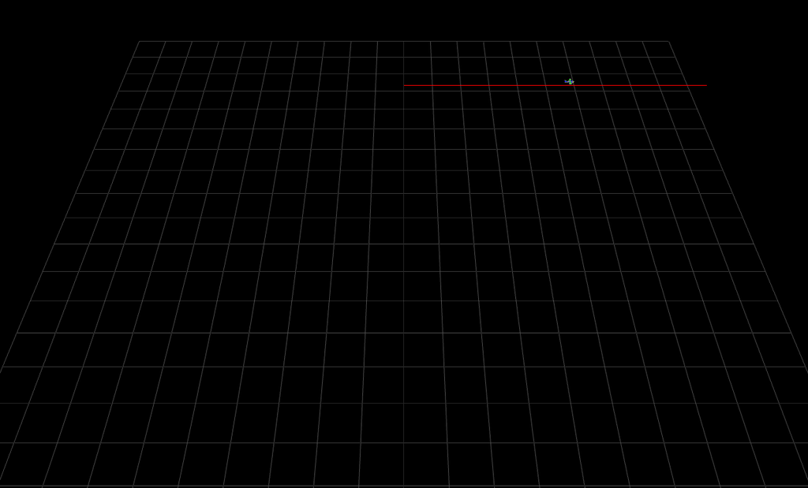

```python
# Problem 6: Switching control with no transition
w0 = np.array([[0.0, 0.0, -100.0]]).T
w1 = np.array([[600.0, 0.0, -100.0]]).T
w2 = np.array([[600.0, 1.0, -100.0]]).T

# Line segment w0 -> w1
path_seg1 = MsgPath()
path_seg1.type = "line"
path_seg1.airspeed = 25.0
path_seg1.line_origin = w0
q1 = w1 - w0
path_seg1.line_direction = q1 / np.linalg.norm(q1)

# Line segment w1 -> w2
path_seg2 = MsgPath()
path_seg2.type = "line"
path_seg2.airspeed = 25.0
path_seg2.line_origin = w1
q2 = w2 - w1
path_seg2.line_direction = q2 / np.linalg.norm(q2)

def switching_path(time: float, state: MsgState) -> MsgPath:
    if state.north >= 600.0:
        return path_seg2
    else:
        return path_seg1

run_sim_and_display(path_fnc=switching_path)
```

## Problem 7: Switching control with arc transition

Repeat problem 6, but instead of having a hard switch between $\overline{w_0 w_1}$ and $\overline{w_1 w_2}$, you will use a circular arc of radius 150 m to perform the switch. Create a circular orbit such that it has exactly one tangent point on $\overline{w_0 w_1}$ and one on $\overline{w_1 w_2}$. Switch to the arc when the aircraft north state has reached the value of the tangent point. Switch from executing the arc to executing $\overline{w_1 w_2}$ when the aircraft east state has reached the value of the tangent point.

### Describe the quality of the path following

The path following is significantly improved compared to Problem 6. The circular arc provides a smooth, continuous transition between the two line segments, eliminating the abrupt course change. The aircraft follows the arc naturally since the tangent points ensure continuity of the commanded heading, resulting in minimal overshoot and a clean turn from northward to eastward flight.

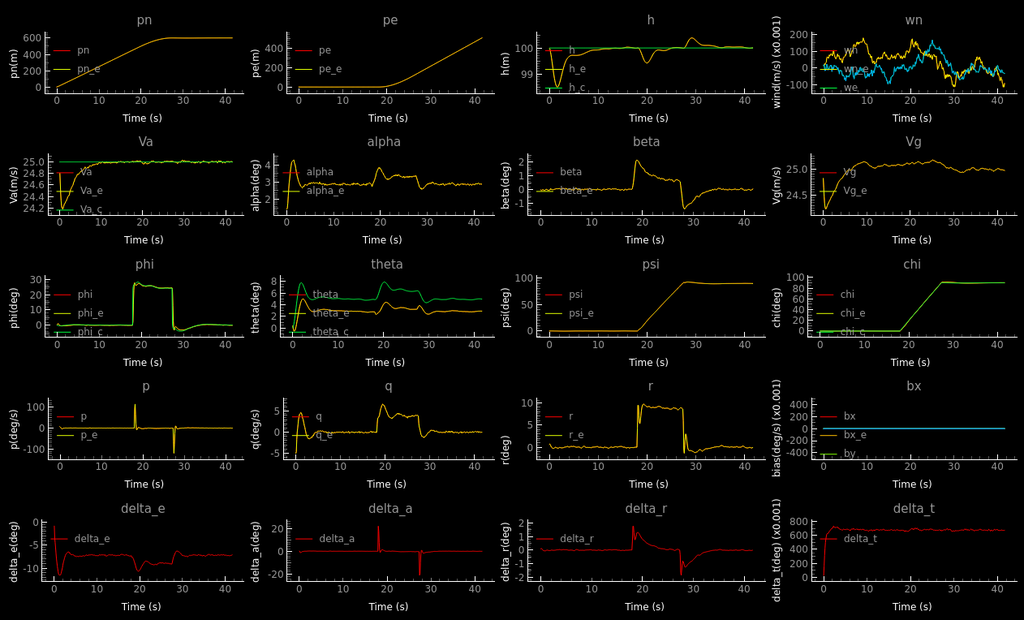

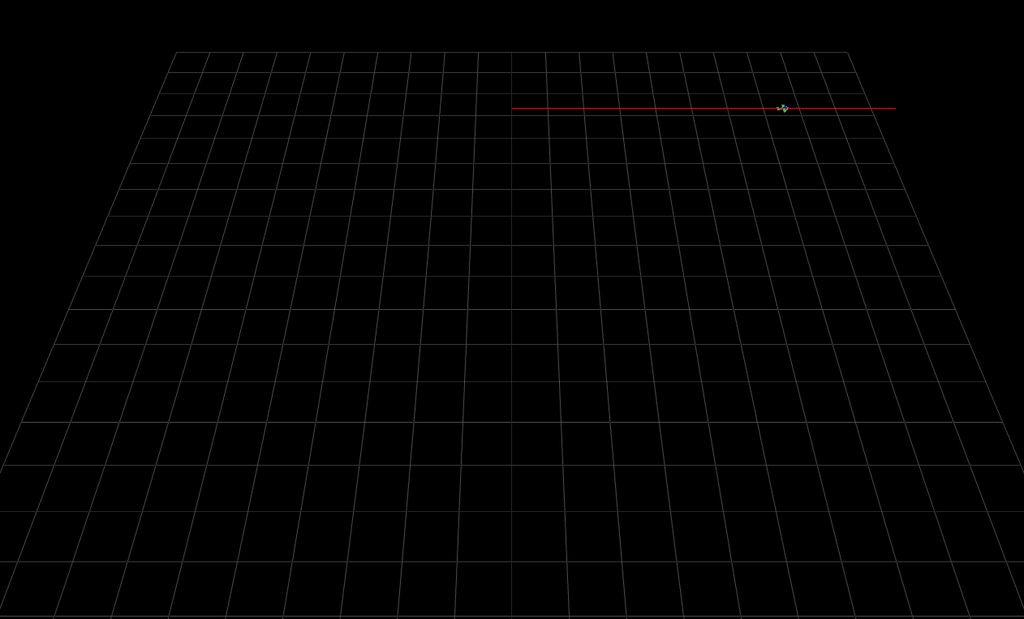

```python
# Problem 7: Switching control with arc transition (radius = 150 m)
w0 = np.array([[0.0, 0.0, -100.0]]).T
w1 = np.array([[600.0, 0.0, -100.0]]).T
w2 = np.array([[600.0, 1.0, -100.0]]).T
R = 150.0

# Line 1 direction: north (1, 0, 0)
# Line 2 direction: east (0, 1, 0)
# For a CW arc turning from north to east:
#   Tangent point on line 1: (600 - R, 0, -100) = (450, 0, -100)
#   Tangent point on line 2: (600, R, -100) = (600, 150, -100)
#   Orbit center: (450, 150, -100)

# Line segment w0 -> w1
path_l1 = MsgPath()
path_l1.type = "line"
path_l1.airspeed = 25.0
path_l1.line_origin = w0
q1 = w1 - w0
path_l1.line_direction = q1 / np.linalg.norm(q1)

# Arc transition
path_arc = MsgPath()
path_arc.type = "orbit"
path_arc.airspeed = 25.0
path_arc.orbit_center = np.array([[450.0, 150.0, -100.0]]).T
path_arc.orbit_radius = R
path_arc.orbit_direction = "CW"

# Line segment w1 -> w2
path_l2 = MsgPath()
path_l2.type = "line"
path_l2.airspeed = 25.0
path_l2.line_origin = w1
q2 = w2 - w1
path_l2.line_direction = q2 / np.linalg.norm(q2)

tangent_north = 450.0  # north value of tangent point on line 1
tangent_east = 150.0   # east value of tangent point on line 2

def arc_transition_path(time: float, state: MsgState) -> MsgPath:
    if state.north < tangent_north:
        return path_l1
    elif state.east < tangent_east:
        return path_arc
    else:
        return path_l2

run_sim_and_display(path_fnc=arc_transition_path)
```

## Static analysis

Run the static code analysis (you must have zero static code analysis errors to get credit). You may not modify the static code analysis configuration files.

### ISORT

Run Isort:

```
python -m isort mav_sim book_assignments
```

Terminal output (should be nothing):

### MyPy

Run MyPy

```
python -m mypy mav_sim/chap2/ mav_sim/chap3/ mav_sim/chap4/ mav_sim/chap5/ mav_sim/chap6/ mav_sim/chap10/ book_assignments
```

Terminal output (should indicate no error):

```
Success: no issues found in 42 source files
```

### Pylint

Run Pylint

```
python -m pylint --jobs 0 --rcfile .pylintrc mav_sim/chap2/ mav_sim/chap3/ mav_sim/chap4/ mav_sim/chap5/ mav_sim/chap6/ mav_sim/chap10/ book_assignments/
```

Terminal output (should indicate `10/10`)

```
Your code has been rated at 10.00/10 (previous run: 10.00/10, +0.00)
```

## Simple code checking

The following code does not need to change. It should just be used as a sanity check so that you know the code is implemented properly. The output should not have any lines reading `Failed test!`

```python
from mav_sim.unit_tests.ch10_path_follower_test import run_all_tests
run_all_tests()
```

```
Starting follow_straight_line test
End of test

Starting follow_orbit test
End of test
```